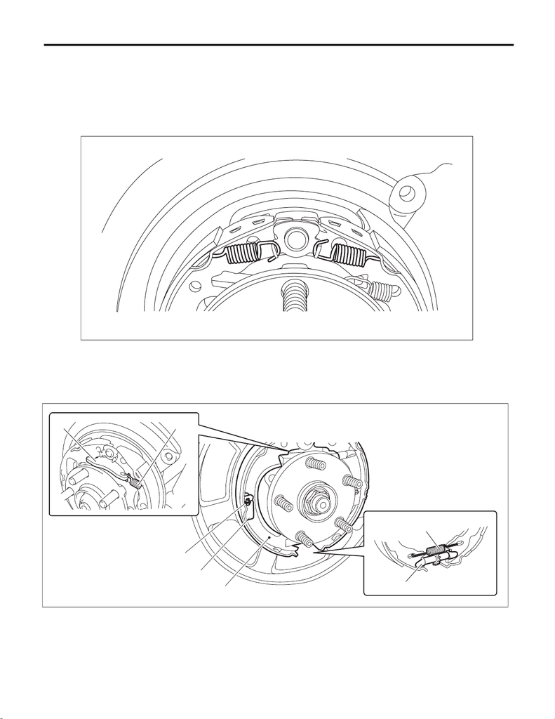

PB-12

Parking Brake Assembly (Rear Disc Brake)

PARKING BRAKE

4. Parking Brake Assembly (Rear Disc Brake)

A: REMOVAL

1) Release the parking brake.

2) Lift up the vehicle, and then remove the rear wheels.

3) Remove the rear disc rotor. <Ref. to BR-39, REMOVAL, Rear Disc Rotor.>

4) Remove the spring - primary shoe return and the spring - secondary shoe return.

5) Remove the parking brake shoe on the primary side.

(1) Remove the strut - brake (a) and the spring - strut (b).

(2) Remove the adjuster assembly - rear brake (c) and the spring - adjuster (d).

(3) Remove the pin - shoe hold-down (e) and the spring - shoe clamp (f), and remove the parking brake

shoe (g).

PB-00248

PB-00351

(f)

(g)

(e)

(c)

(d)

(b)

(a)

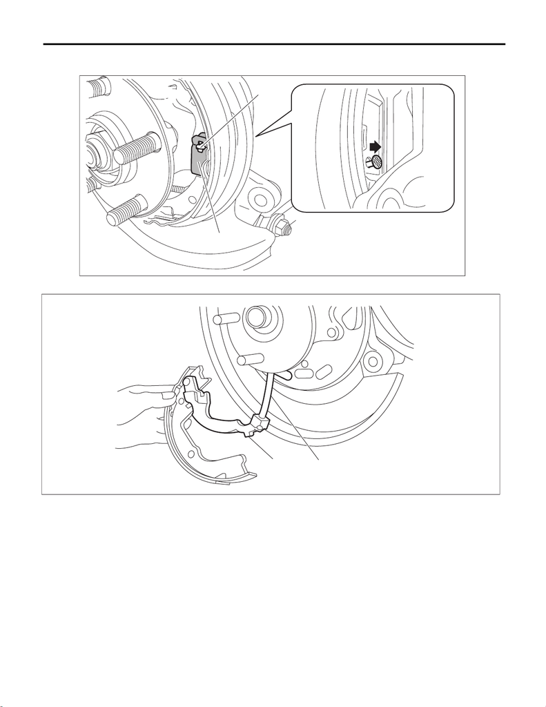

PB-13

Parking Brake Assembly (Rear Disc Brake)

PARKING BRAKE

6) Remove the pin - shoe hold-down (a) and the spring - shoe clamp (b), and remove the secondary side

parking brake shoe.

7) Remove the cable assembly - hand brake cable (a) from the parking lever - rear (b).

8) Remove the retainer - rear brake and the spring washer - rear brake, and remove the parking lever - rear

and the brake shoe.

PB-00352

(b)

(a)

PB-00250

(a)

(b)

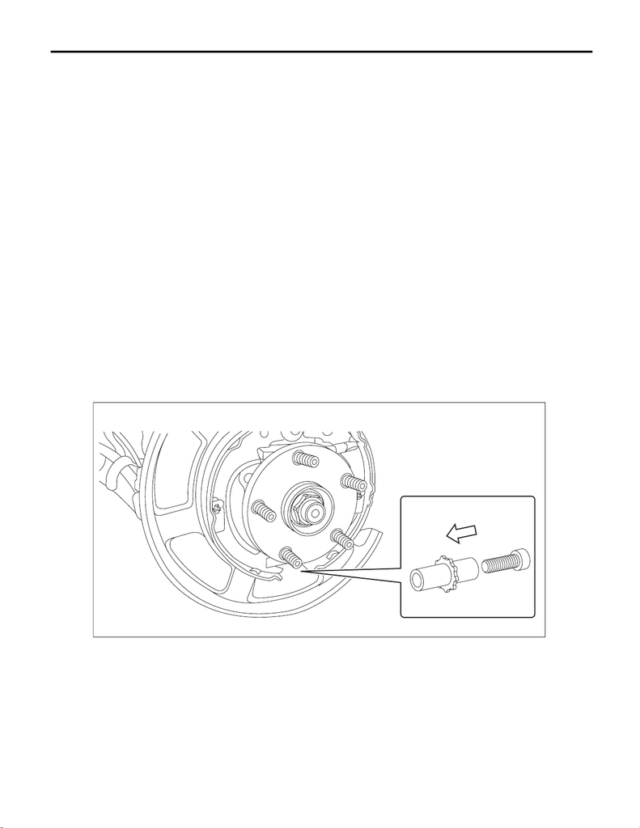

PB-14

Parking Brake Assembly (Rear Disc Brake)

PARKING BRAKE

B: INSTALLATION

CAUTION:

Be sure the lining surface is free from brake fluid and grease.

1) Apply brake grease to the following locations.

Brake grease:

Molykote44MA or equivalent

• Six contact surfaces of the parking brake shoe rim and back plate - rear brake

• Contact surface of the parking brake shoe and the anchor pin

• Contact surface of the parking lever assembly - rear and the strut - brake

• Contact surface of the parking brake shoe and the adjuster assembly - rear brake

• Contact surface of the parking brake shoe and the strut - brake

• Contact surface of the parking lever - rear and the parking brake shoe

2) Install the parking lever - rear to the secondary side parking brake shoe.

NOTE:

Install the pin - parking lever and spring washer - rear brake to the parking lever - rear, and swage the

retainer - rear brake to secure.

3) Install the cable assembly - parking brake to the parking lever - rear.

NOTE:

Check that the cable assembly - parking brake does not fall from the cable guide.

4) Attach the adjuster assembly - rear brake and the spring - adjuster to the primary side and the secondary

side parking brake shoes.

NOTE:

Install the adjuster assembly - rear brake with the screw section facing to the direction shown in the figure be-

low.

(F) Left wheel: front side of vehicle,

right wheel: rear side of vehicle

PB-00345

(F)

[figure not shown]

PB-15

Parking Brake Assembly (Rear Disc Brake)

PARKING BRAKE

5) Install the parking brake shoes to the back plate - rear brake with the pins - shoe hold-down and the

springs - shoe clamp.

6) Install the strut - brake and the spring - strut to the parking brake shoes.

NOTE:

Install the spring - strut so that it comes towards the front side of the vehicle.

7) Install the return springs on the primary side first, and then the secondary side.

8) Install the disc rotor and the disc brake assembly - rear.

Tightening torque:

STI model: 65 N·m (6.6 kgf-m, 47.9 ft-lb)

Except for STI model: 66 N·m (6.7 kgf-m, 48.7 ft-lb)

9) Adjust the parking brake. <Ref. to PB-16, ADJUSTMENT, Parking Brake Assembly (Rear Disc Brake).>

10) Install the rear wheels.

Tightening torque:

120 N·m (12.2 kgf-m, 88.5 ft-lb)

11) If new parking brake shoes are replaced, drive the vehicle to break-in the parking brake lining.

(1) Drive the vehicle at approximately 35 km/h (22 MPH) or more.

(2) While pressing the button of lever assembly - hand brake, pull the lever assembly - hand brake with

a force of 150 N (15.3 kgf, 33.7 lbf).

(3) Drive the vehicle for about 200 m (0.12 mile) in this condition.

(4) Wait 5 to 10 minutes for the parking brake to cool down. Repeat steps (1) through (3) again.

(5) After breaking-in, re-adjust the parking brakes. <Ref. to PB-16, ADJUSTMENT, Parking Brake As-

sembly (Rear Disc Brake).>

C: INSPECTION

1) Measure the inner diameter of the rear disc rotor. If scoring or worn is found on the disc, replace the rear

disc rotor.

Disc rotor inner diameter:

Specification: 190 mm (7.48 in)

Service limit: 191 mm (7.52 in)

2) Measure the lining thickness. If it exceeds the limit, replace the brake shoe.

Lining thickness:

Specification: 3.5 mm (0.14 in)

Service limit: 1.5 mm (0.059 in)

NOTE:

Replace the right and left parking brake shoe as a set.

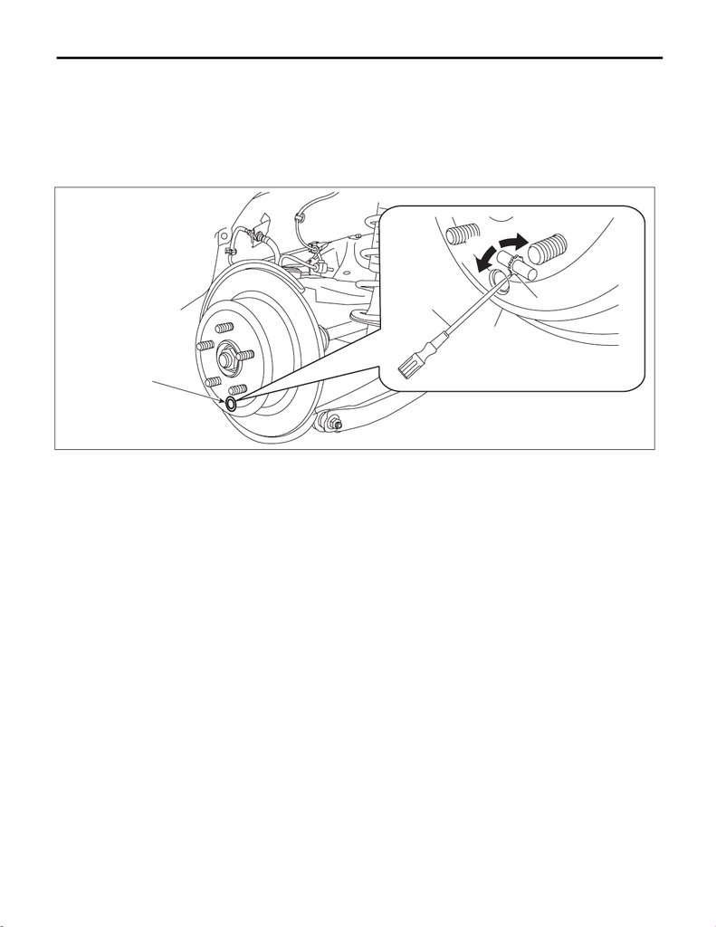

PB-16

Parking Brake Assembly (Rear Disc Brake)

PARKING BRAKE

D: ADJUSTMENT

1. SHOE CLEARANCE

1) Return the lever assembly - hand brake completely.

2) Loosen the adjusting nut, and make the cable free.

3) Remove the adjusting hole cover (A).

4) Insert a flat tip screwdriver (b) into the adjustment hole, and rotate the adjuster assembly - rear brake (a)

until the disc rotor cannot be turned by hand.

5) Loosen the adjuster assembly - rear brake by 10 notches in the direction of the arrow (e).

CAUTION:

• Check there is no brake drag.

• Make sure that the adjuster assembly - rear brake is loosened by 10 notches. If it is not loosened

sufficiently, dragging may occur.

6) Install the adjusting hole cover to the disc rotor.

7) Adjust the parking lever stroke. <Ref. to PB-17, LEVER STROKE, ADJUSTMENT, Parking Brake Assem-

bly (Rear Disc Brake).>

(a) Adjuster ASSY - rear brake (c) Disc rotor (e) Shorten the adjuster ASSY - rear

brake

(b) Flat tip screwdriver (d) Extend the adjuster ASSY - rear

brake

PB-00247

(A)

(b)

(c)

(a)

(d)

(e)

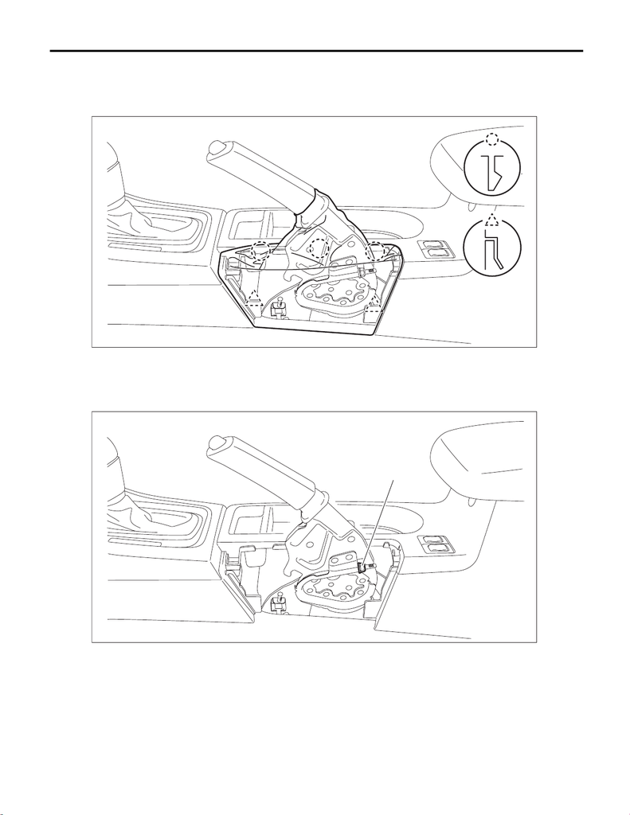

PB-17

Parking Brake Assembly (Rear Disc Brake)

PARKING BRAKE

2. LEVER STROKE

1) Adjust the shoe clearance before adjusting lever stroke. <Ref. to PB-16, SHOE CLEARANCE, ADJUST-

MENT, Parking Brake Assembly (Rear Disc Brake).>

2) Release the claws, and then remove the boot - parking brake.

3) Pull the lever assembly - hand brake hard 3 to 5 times.

4) Turn the adjusting nut (a) until the lever stroke is at the specified value.

Lever stroke:

7 to 8 notches when pulled with a force of 200 N (20.4 kgf, 45 lbf)

5) Check there is no brake drag.

6) Check that the brake warning light illuminates when the lever assembly - hand brake is operated.

NOTE:

The light must illuminate when the first notch is reached after pulling the lever.

7) Install the boot - parking brake.

EI-04276

PB-00348

(a)